# Problema 1 - Checkpoint 4

Lucas Marlon

26 de maio de 2017

## Relatório Final

### Pergunta 1

A primeira pergunta que escolhi foi: **Qual das séries possui maior avaliação na primeira temporada?**

Inicialmente essa pergunta foi pensada para ser respondida usando os dados de todas as séries, porém percebi que a quantidade de séries é um pouco grande e isso pode dificultar a obtenção dos resultados. Sendo assim, resolvi ficar com as três séries que escolhi no checkpoint 1, *Friends*, *How I Met Your Mother* e *Modern Family*.

Inicialmente vamos verificar a frequência de notas dentre a classificação dos usuários para cada uma das séries, assim podemos explicar melhor a variável a ser avaliada.

### Friends

No gráfico abaixo podemos observar a frequência das classificações dos usuários para a série *Friends* para a primeira temporada da série. Conseguimos perceber que a maior frequência de classificações é da nota 8.5, o que nos faz esperar que a média e a mediana durante a primeira temporada estejam próximas desse valor.

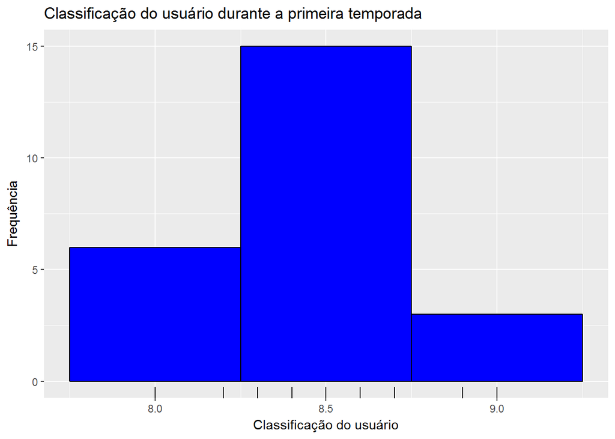

```r
series %>%
  filter(series_name == "Friends", season == 1) %>%
    ggplot(aes(x = UserRating)) +
    geom_histogram(binwidth = .5, fill = "blue", color = "black") +
    geom_rug() +
  labs(title = "Classificação do usuário durante a primeira temporada", x = "Classificação do usuário", y = "Frequência")
```

### How I Met Your Mother

No gráfico abaixo podemos observar a frequência das classificações dos usuários para a série *How I Met Your Mother* para a primeira temporada da série. Conseguimos perceber que a maior frequência de classificações está entre as notas 8.0 e ~8.5, o que nos faz esperar que a média e a mediana durante a primeira temporada estejam próximas desse valor.

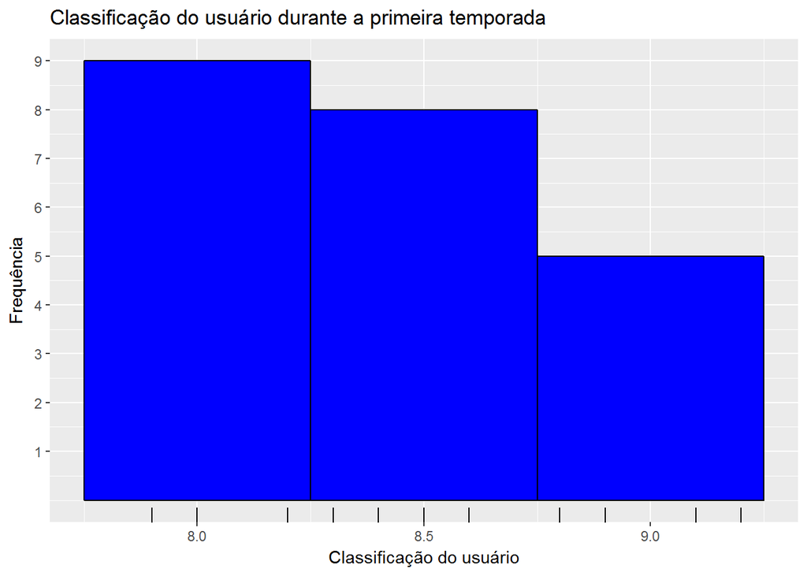

```r
series %>%
  filter(series_name == "How I Met Your Mother", season == 1) %>%
    ggplot(aes(x = UserRating)) +
    geom_histogram(binwidth = .5, fill = "blue", color = "black") +
    scale_y_continuous(breaks=seq(1, 10, 1))+
    geom_rug() +
  labs(title = "Classificação do usuário durante a primeira temporada", x = "Classificação do usuário", y = "Frequência")
```